# Optimal Treatment Analysis

## Outcome Variable

**Outcome Variable:** whz

## Predictor Variables

**Intervention Variable:** hfoodsec

**Adjustment Set:**

- arm
- sex
- W_mage
- meducyrs
- feducyrs
- hhwealth_quart
- vagbrth
- W_nrooms
- W_nchldlt5
- brthmon
- W_parity
- impfloor
- impsan
- safeh20
- delta_W_mage
- delta_meducyrs
- delta_feducyrs
- delta_hhwealth_quart
- delta_vagbrth
- delta_W_nrooms
- delta_W_nchldlt5
- delta_brthmon
- delta_W_parity
- delta_impfloor
- delta_impsan
- delta_safeh20

## Stratifying Variables

The analysis was stratified on these variable(s):

- agecat
- studyid
- country

## Data Summary

| agecat | studyid | country | hfoodsec | n_cell | n |
| --- | --- | --- | --- | --- | --- |
| Birth | ki0047075b-MAL-ED | BANGLADESH | Food Secure | 151 | 178 |
| Birth | ki0047075b-MAL-ED | BANGLADESH | Mildly Food Insecure | 3 | 178 |
| Birth | ki0047075b-MAL-ED | BANGLADESH | Food Insecure | 24 | 178 |
| Birth | ki0047075b-MAL-ED | BRAZIL | Food Secure | 0 | 102 |
| Birth | ki0047075b-MAL-ED | BRAZIL | Mildly Food Insecure | 11 | 102 |
| Birth | ki0047075b-MAL-ED | BRAZIL | Food Insecure | 91 | 102 |
| Birth | ki0047075b-MAL-ED | INDIA | Food Secure | 151 | 167 |
| Birth | ki0047075b-MAL-ED | INDIA | Mildly Food Insecure | 2 | 167 |
| Birth | ki0047075b-MAL-ED | INDIA | Food Insecure | 14 | 167 |
| Birth | ki0047075b-MAL-ED | NEPAL | Food Secure | 75 | 96 |
| Birth | ki0047075b-MAL-ED | NEPAL | Mildly Food Insecure | 9 | 96 |
| Birth | ki0047075b-MAL-ED | NEPAL | Food Insecure | 12 | 96 |
| Birth | ki0047075b-MAL-ED | PERU | Food Secure | 26 | 105 |
| Birth | ki0047075b-MAL-ED | PERU | Mildly Food Insecure | 24 | 105 |
| Birth | ki0047075b-MAL-ED | PERU | Food Insecure | 55 | 105 |
| Birth | ki0047075b-MAL-ED | SOUTH AFRICA | Food Secure | 106 | 193 |
| Birth | ki0047075b-MAL-ED | SOUTH AFRICA | Mildly Food Insecure | 17 | 193 |
| Birth | ki0047075b-MAL-ED | SOUTH AFRICA | Food Insecure | 70 | 193 |
| Birth | ki1017093-NIH-Birth | BANGLADESH | Food Secure | 3 | 28 |
| Birth | ki1017093-NIH-Birth | BANGLADESH | Mildly Food Insecure | 21 | 28 |
| Birth | ki1017093-NIH-Birth | BANGLADESH | Food Insecure | 4 | 28 |
| Birth | ki1017093c-NIH-Crypto | BANGLADESH | Food Secure | 14 | 23 |
| Birth | ki1017093c-NIH-Crypto | BANGLADESH | Mildly Food Insecure | 6 | 23 |
| Birth | ki1017093c-NIH-Crypto | BANGLADESH | Food Insecure | 3 | 23 |
| Birth | kiGH5241-JiVitA-3 | BANGLADESH | Food Secure | 4974 | 10289 |
| Birth | kiGH5241-JiVitA-3 | BANGLADESH | Mildly Food Insecure | 3502 | 10289 |
| Birth | kiGH5241-JiVitA-3 | BANGLADESH | Food Insecure | 1813 | 10289 |
| Birth | kiGH5241-JiVitA-4 | BANGLADESH | Food Secure | 334 | 680 |
| Birth | kiGH5241-JiVitA-4 | BANGLADESH | Mildly Food Insecure | 250 | 680 |
| Birth | kiGH5241-JiVitA-4 | BANGLADESH | Food Insecure | 96 | 680 |

[output cut: 66 more lines]

The following strata were considered:

- agecat: 24 months, studyid: ki0047075b-MAL-ED, country: BANGLADESH
- agecat: 24 months, studyid: ki0047075b-MAL-ED, country: BRAZIL
- agecat: 24 months, studyid: ki0047075b-MAL-ED, country: INDIA
- agecat: 24 months, studyid: ki0047075b-MAL-ED, country: NEPAL
- agecat: 24 months, studyid: ki0047075b-MAL-ED, country: PERU
- agecat: 24 months, studyid: ki0047075b-MAL-ED, country: SOUTH AFRICA
- agecat: 24 months, studyid: ki1017093-NIH-Birth, country: BANGLADESH
- agecat: 24 months, studyid: ki1017093c-NIH-Crypto, country: BANGLADESH
- agecat: 24 months, studyid: ki1113344-GMS-Nepal, country: NEPAL
- agecat: 24 months, studyid: kiGH5241-JiVitA-3, country: BANGLADESH
- agecat: 24 months, studyid: kiGH5241-JiVitA-4, country: BANGLADESH
- agecat: 6 months, studyid: ki0047075b-MAL-ED, country: BANGLADESH
- agecat: 6 months, studyid: ki0047075b-MAL-ED, country: BRAZIL
- agecat: 6 months, studyid: ki0047075b-MAL-ED, country: INDIA
- agecat: 6 months, studyid: ki0047075b-MAL-ED, country: NEPAL
- agecat: 6 months, studyid: ki0047075b-MAL-ED, country: PERU
- agecat: 6 months, studyid: ki0047075b-MAL-ED, country: SOUTH AFRICA
- agecat: 6 months, studyid: ki1017093-NIH-Birth, country: BANGLADESH
- agecat: 6 months, studyid: ki1017093c-NIH-Crypto, country: BANGLADESH
- agecat: 6 months, studyid: ki1113344-GMS-Nepal, country: NEPAL
- agecat: 6 months, studyid: kiGH5241-JiVitA-3, country: BANGLADESH
- agecat: 6 months, studyid: kiGH5241-JiVitA-4, country: BANGLADESH
- agecat: Birth, studyid: ki0047075b-MAL-ED, country: BANGLADESH
- agecat: Birth, studyid: ki0047075b-MAL-ED, country: BRAZIL
- agecat: Birth, studyid: ki0047075b-MAL-ED, country: INDIA
- agecat: Birth, studyid: ki0047075b-MAL-ED, country: NEPAL
- agecat: Birth, studyid: ki0047075b-MAL-ED, country: PERU
- agecat: Birth, studyid: ki0047075b-MAL-ED, country: SOUTH AFRICA
- agecat: Birth, studyid: ki1017093-NIH-Birth, country: BANGLADESH
- agecat: Birth, studyid: ki1017093c-NIH-Crypto, country: BANGLADESH
- agecat: Birth, studyid: kiGH5241-JiVitA-3, country: BANGLADESH
- agecat: Birth, studyid: kiGH5241-JiVitA-4, country: BANGLADESH

### Dropped Strata

Some strata were dropped due to rare outcomes:

- agecat: Birth, studyid: ki0047075b-MAL-ED, country: BANGLADESH
- agecat: Birth, studyid: ki0047075b-MAL-ED, country: BRAZIL
- agecat: Birth, studyid: ki0047075b-MAL-ED, country: INDIA
- agecat: Birth, studyid: ki1017093-NIH-Birth, country: BANGLADESH
- agecat: Birth, studyid: ki1017093c-NIH-Crypto, country: BANGLADESH
- agecat: 6 months, studyid: ki0047075b-MAL-ED, country: BANGLADESH
- agecat: 6 months, studyid: ki0047075b-MAL-ED, country: BRAZIL
- agecat: 24 months, studyid: ki0047075b-MAL-ED, country: BANGLADESH
- agecat: 24 months, studyid: ki0047075b-MAL-ED, country: BRAZIL

## Methods Detail

We’re interested in the causal parameters $E[Y_a]$ for all values of $a \in \mathcal{A}$. These parameters represent the mean outcome if, possibly contrary to fact, we intervened to set all units to have $A=a$. Under the randomization and positivity assumptions, these are identified by the statistical parameters $\psi_a=E_W[E_{Y|A,W}(Y|A=a,W)]$. In addition, we’re interested in the mean of $Y$, $E[Y]$ under no intervention (the observed mean). We will estimate these parameters by using SuperLearner to fit the relevant likelihood factors – $E_{Y|A,W}(Y|A=a,W)$ and $p(A=a|W)$, and then updating our likelihood fit using a joint TMLE.

For unadjusted analyses ($W=\{\}$), initial likelihoods were estimated using Lrnr_glm to estimate the simple $E(Y|A)$ and Lrnr_mean to estimate $p(A)$. For adjusted analyses, a small library containing Lrnr_glmnet, Lrnr_xgboost, and Lrnr_mean was used.

Having estimated these parameters, we will then use the delta method to estimate relative risks and attributable risks relative to a prespecified baseline level of $A$.

# Results Detail

## Results Plots

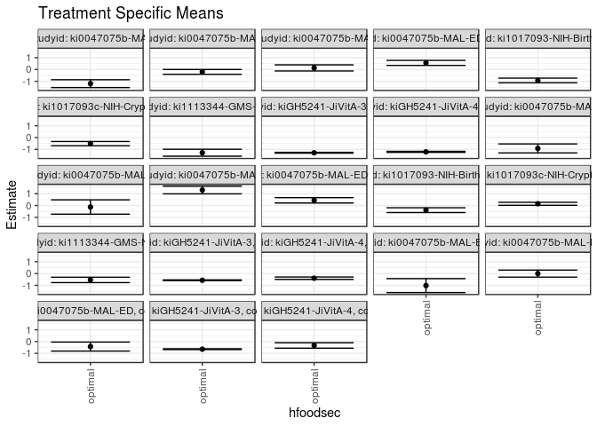

## Results Table

### Parameter: TSM

| agecat | studyid | country | intervention_level | baseline_level | estimate | ci_lower | ci_upper |
| --- | --- | --- | --- | --- | --- | --- | --- |
| Birth | ki0047075b-MAL-ED | NEPAL | optimal | observed | -1.0201159 | -1.6111939 | -0.4290380 |
| Birth | ki0047075b-MAL-ED | PERU | optimal | observed | -0.0027829 | -0.3004482 | 0.2948824 |
| Birth | ki0047075b-MAL-ED | SOUTH AFRICA | optimal | observed | -0.4253957 | -0.8056130 | -0.0451785 |
| Birth | kiGH5241-JiVitA-3 | BANGLADESH | optimal | observed | -0.6431068 | -0.6775762 | -0.6086374 |
| Birth | kiGH5241-JiVitA-4 | BANGLADESH | optimal | observed | -0.3302175 | -0.5585469 | -0.1018881 |
| 6 months | ki0047075b-MAL-ED | INDIA | optimal | observed | -0.9217130 | -1.3024742 | -0.5409519 |
| 6 months | ki0047075b-MAL-ED | NEPAL | optimal | observed | -0.1245679 | -0.7322863 | 0.4831505 |
| 6 months | ki0047075b-MAL-ED | PERU | optimal | observed | 1.3139723 | 0.9867008 | 1.6412437 |
| 6 months | ki0047075b-MAL-ED | SOUTH AFRICA | optimal | observed | 0.4404988 | 0.2141542 | 0.6668433 |
| 6 months | ki1017093-NIH-Birth | BANGLADESH | optimal | observed | -0.3913787 | -0.5932055 | -0.1895520 |
| 6 months | ki1017093c-NIH-Crypto | BANGLADESH | optimal | observed | 0.1477359 | 0.0224210 | 0.2730507 |
| 6 months | ki1113344-GMS-Nepal | NEPAL | optimal | observed | -0.5387004 | -0.7663758 | -0.3110250 |
| 6 months | kiGH5241-JiVitA-3 | BANGLADESH | optimal | observed | -0.5674961 | -0.5952147 | -0.5397774 |
| 6 months | kiGH5241-JiVitA-4 | BANGLADESH | optimal | observed | -0.3924004 | -0.4947290 | -0.2900719 |
| 24 months | ki0047075b-MAL-ED | INDIA | optimal | observed | -1.1953985 | -1.5276664 | -0.8631307 |
| 24 months | ki0047075b-MAL-ED | NEPAL | optimal | observed | -0.1996968 | -0.4024100 | 0.0030165 |
| 24 months | ki0047075b-MAL-ED | PERU | optimal | observed | 0.1348630 | -0.1243265 | 0.3940525 |
| 24 months | ki0047075b-MAL-ED | SOUTH AFRICA | optimal | observed | 0.5597465 | 0.3478737 | 0.7716193 |
| 24 months | ki1017093-NIH-Birth | BANGLADESH | optimal | observed | -0.9268874 | -1.1254818 | -0.7282931 |
| 24 months | ki1017093c-NIH-Crypto | BANGLADESH | optimal | observed | -0.5163400 | -0.6965735 | -0.3361066 |
| 24 months | ki1113344-GMS-Nepal | NEPAL | optimal | observed | -1.2861903 | -1.5807229 | -0.9916576 |
| 24 months | kiGH5241-JiVitA-3 | BANGLADESH | optimal | observed | -1.2890480 | -1.3228645 | -1.2552315 |
| 24 months | kiGH5241-JiVitA-4 | BANGLADESH | optimal | observed | -1.2120138 | -1.2565342 | -1.1674934 |

### Parameter: E(Y)

| agecat | studyid | country | intervention_level | baseline_level | estimate | ci_lower | ci_upper |
| --- | --- | --- | --- | --- | --- | --- | --- |
| Birth | ki0047075b-MAL-ED | NEPAL | observed | observed | -0.9503125 | -1.1412124 | -0.7594126 |
| Birth | ki0047075b-MAL-ED | PERU | observed | observed | -0.0395238 | -0.2249300 | 0.1458824 |
| Birth | ki0047075b-MAL-ED | SOUTH AFRICA | observed | observed | 0.0036788 | -0.1626160 | 0.1699735 |
| Birth | kiGH5241-JiVitA-3 | BANGLADESH | observed | observed | -0.6992565 | -0.7232731 | -0.6752399 |
| Birth | kiGH5241-JiVitA-4 | BANGLADESH | observed | observed | -0.3680294 | -0.4489214 | -0.2871374 |
| 6 months | ki0047075b-MAL-ED | INDIA | observed | observed | -0.7155110 | -0.8495147 | -0.5815073 |
| 6 months | ki0047075b-MAL-ED | NEPAL | observed | observed | 0.1289063 | -0.0638567 | 0.3216692 |
| 6 months | ki0047075b-MAL-ED | PERU | observed | observed | 0.9790991 | 0.7644567 | 1.1937415 |
| 6 months | ki0047075b-MAL-ED | SOUTH AFRICA | observed | observed | 0.5422442 | 0.3806254 | 0.7038629 |
| 6 months | ki1017093-NIH-Birth | BANGLADESH | observed | observed | -0.4389101 | -0.5279432 | -0.3498771 |
| 6 months | ki1017093c-NIH-Crypto | BANGLADESH | observed | observed | 0.0297622 | -0.0491685 | 0.1086930 |
| 6 months | ki1113344-GMS-Nepal | NEPAL | observed | observed | -0.6028654 | -0.6902793 | -0.5154516 |
| 6 months | kiGH5241-JiVitA-3 | BANGLADESH | observed | observed | -0.5932301 | -0.6127836 | -0.5736767 |
| 6 months | kiGH5241-JiVitA-4 | BANGLADESH | observed | observed | -0.3895527 | -0.4270314 | -0.3520739 |
| 24 months | ki0047075b-MAL-ED | INDIA | observed | observed | -0.9595519 | -1.0781202 | -0.8409836 |
| 24 months | ki0047075b-MAL-ED | NEPAL | observed | observed | -0.2757812 | -0.4379560 | -0.1136065 |
| 24 months | ki0047075b-MAL-ED | PERU | observed | observed | 0.0979907 | -0.0798724 | 0.2758537 |
| 24 months | ki0047075b-MAL-ED | SOUTH AFRICA | observed | observed | 0.4264693 | 0.3032402 | 0.5496984 |
| 24 months | ki1017093-NIH-Birth | BANGLADESH | observed | observed | -0.9115790 | -1.0095022 | -0.8136559 |
| 24 months | ki1017093c-NIH-Crypto | BANGLADESH | observed | observed | -0.6103502 | -0.7050157 | -0.5156847 |
| 24 months | ki1113344-GMS-Nepal | NEPAL | observed | observed | -1.1257803 | -1.2146168 | -1.0369438 |
| 24 months | kiGH5241-JiVitA-3 | BANGLADESH | observed | observed | -1.2988352 | -1.3224626 | -1.2752078 |
| 24 months | kiGH5241-JiVitA-4 | BANGLADESH | observed | observed | -1.2243590 | -1.2566569 | -1.1920612 |

### Parameter: PAR

| agecat | studyid | country | intervention_level | baseline_level | estimate | ci_lower | ci_upper |
| --- | --- | --- | --- | --- | --- | --- | --- |
| Birth | ki0047075b-MAL-ED | NEPAL | optimal | observed | 0.0698034 | -0.5009920 | 0.6405989 |
| Birth | ki0047075b-MAL-ED | PERU | optimal | observed | -0.0367409 | -0.2817774 | 0.2082956 |
| Birth | ki0047075b-MAL-ED | SOUTH AFRICA | optimal | observed | 0.4290745 | 0.0728681 | 0.7852809 |
| Birth | kiGH5241-JiVitA-3 | BANGLADESH | optimal | observed | -0.0561497 | -0.0802897 | -0.0320097 |
| Birth | kiGH5241-JiVitA-4 | BANGLADESH | optimal | observed | -0.0378119 | -0.2486089 | 0.1729850 |
| 6 months | ki0047075b-MAL-ED | INDIA | optimal | observed | 0.2062020 | -0.1499299 | 0.5623340 |
| 6 months | ki0047075b-MAL-ED | NEPAL | optimal | observed | 0.2534741 | -0.3004343 | 0.8073825 |
| 6 months | ki0047075b-MAL-ED | PERU | optimal | observed | -0.3348732 | -0.6182001 | -0.0515462 |
| 6 months | ki0047075b-MAL-ED | SOUTH AFRICA | optimal | observed | 0.1017454 | -0.0924856 | 0.2959764 |
| 6 months | ki1017093-NIH-Birth | BANGLADESH | optimal | observed | -0.0475314 | -0.2378146 | 0.1427518 |
| 6 months | ki1017093c-NIH-Crypto | BANGLADESH | optimal | observed | -0.1179736 | -0.2171377 | -0.0188096 |
| 6 months | ki1113344-GMS-Nepal | NEPAL | optimal | observed | -0.0641650 | -0.2781620 | 0.1498319 |
| 6 months | kiGH5241-JiVitA-3 | BANGLADESH | optimal | observed | -0.0257341 | -0.0455702 | -0.0058980 |
| 6 months | kiGH5241-JiVitA-4 | BANGLADESH | optimal | observed | 0.0028478 | -0.0864424 | 0.0921379 |
| 24 months | ki0047075b-MAL-ED | INDIA | optimal | observed | 0.2358466 | -0.0789176 | 0.5506109 |
| 24 months | ki0047075b-MAL-ED | NEPAL | optimal | observed | -0.0760845 | -0.1735160 | 0.0213470 |
| 24 months | ki0047075b-MAL-ED | PERU | optimal | observed | -0.0368723 | -0.2852697 | 0.2115251 |
| 24 months | ki0047075b-MAL-ED | SOUTH AFRICA | optimal | observed | -0.1332772 | -0.3036020 | 0.0370476 |
| 24 months | ki1017093-NIH-Birth | BANGLADESH | optimal | observed | 0.0153084 | -0.1677060 | 0.1983227 |
| 24 months | ki1017093c-NIH-Crypto | BANGLADESH | optimal | observed | -0.0940102 | -0.2470231 | 0.0590028 |
| 24 months | ki1113344-GMS-Nepal | NEPAL | optimal | observed | 0.1604100 | -0.1163279 | 0.4371479 |
| 24 months | kiGH5241-JiVitA-3 | BANGLADESH | optimal | observed | -0.0097872 | -0.0340070 | 0.0144326 |
| 24 months | kiGH5241-JiVitA-4 | BANGLADESH | optimal | observed | -0.0123453 | -0.0435344 | 0.0188439 |